# **Loan Default Prediction**

## Observations

- This model is not overfitting the training data and the recall score increases to 78% for the test set
- Precision has gone down from 71% to 56%
- The model gives consistent result for the train and test data sets

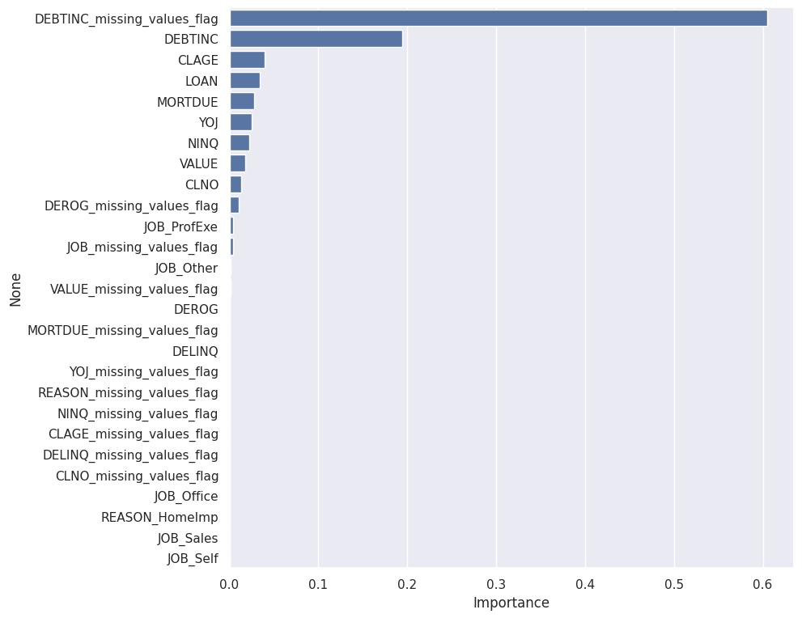

```python
# Checking the tuned decision tree feature importance
importances =d_tree_tuned.feature_importances_
columns = X.columns
importance_df = pd.DataFrame(importances, index = columns, columns = ['Importance']).sort_values(by = 'Importance', ascending = False)
plt.figure(figsize = (9, 9))
sns.barplot(x='Importance', y=importance_df.index, data=importance_df)
```

## Observations

- After tuning the DT model we are getting fewer features that are important.
- According to this model too, the DEBTINC_missing_values_flag is the most important feature, followed by DEBTINC.
- The other features are much less impactful in defaulting on a loan.
- The tuned model is more generalized than the default model.

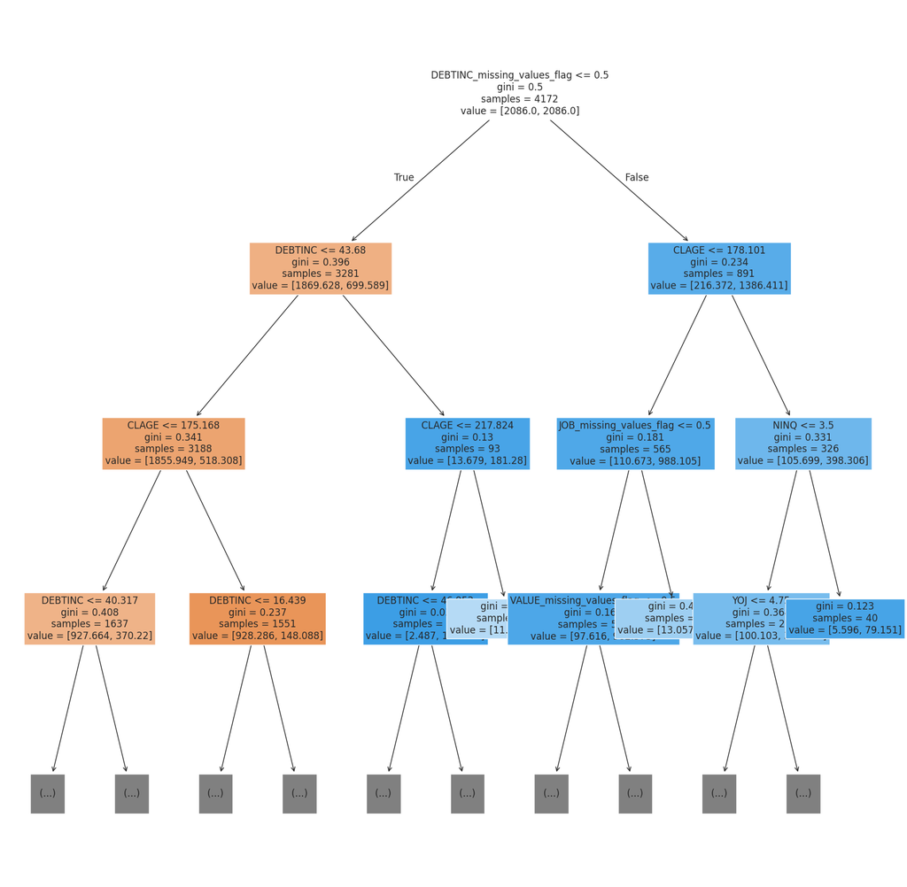

```python
# Plotting the Decision Tree
features = list(X.columns)

plt.figure(figsize = (20, 20))

tree.plot_tree(d_tree_tuned, max_depth = 3, feature_names = features, filled = True, fontsize = 12)

plt.show()
```